# Respostas do texto Zé Gotinha

Da campanha da televisão.

1

1

91

21

Fácil

A imagem mostra o primeiro esboço de Zé Gotinha, isto é, o desenho inicial do personagem, com seus traços gerais. De onde a reportagem selecionou esse desenho?

Localizar elementos espaciais ou temporais em um texto

Da propaganda do Zé Gotinha.

1

1

92

21

Fácil

A imagem mostra o primeiro esboço de Zé Gotinha, isto é, o desenho inicial do personagem, com seus traços gerais. De onde a reportagem selecionou esse desenho?

Localizar elementos espaciais ou temporais em um texto

A reportagem selecionou esse desenho do arquivo pessoal de Darlan Rosa.

3

1

93

21

Fácil

A imagem mostra o primeiro esboço de Zé Gotinha, isto é, o desenho inicial do personagem, com seus traços gerais. De onde a reportagem selecionou esse desenho?

Localizar elementos espaciais ou temporais em um texto

A reportagem selecionou esse desenho do arquivo pessoal de Darlan Rosa.

3

1

94

21

Fácil

A imagem mostra o primeiro esboço de Zé Gotinha, isto é, o desenho inicial do personagem, com seus traços gerais. De onde a reportagem selecionou esse desenho?

Localizar elementos espaciais ou temporais em um texto

ela selecionou como duas gotas

1

1

95

21

Fácil

A imagem mostra o primeiro esboço de Zé Gotinha, isto é, o desenho inicial do personagem, com seus traços gerais. De onde a reportagem selecionou esse desenho?

Localizar elementos espaciais ou temporais em um texto

Eles tiraram d arquivo pessoal de Darlan Rosa.

3

1

96

21

Fácil

A imagem mostra o primeiro esboço de Zé Gotinha, isto é, o desenho inicial do personagem, com seus traços gerais. De onde a reportagem selecionou esse desenho?

Localizar elementos espaciais ou temporais em um texto

dos arquivos pessoais de Darlan Rosa.

3

1

97

21

Fácil

A imagem mostra o primeiro esboço de Zé Gotinha, isto é, o desenho inicial do personagem, com seus traços gerais. De onde a reportagem selecionou esse desenho?

Localizar elementos espaciais ou temporais em um texto

do arquivo pessoal de darlan rosa

3

1

98

21

Fácil

A imagem mostra o primeiro esboço de Zé Gotinha, isto é, o desenho inicial do personagem, com seus traços gerais. De onde a reportagem selecionou esse desenho?

Localizar elementos espaciais ou temporais em um texto

do programa de desenho infantil

1

1

99

21

Fácil

A imagem mostra o primeiro esboço de Zé Gotinha, isto é, o desenho inicial do personagem, com seus traços gerais. De onde a reportagem selecionou esse desenho?

Localizar elementos espaciais ou temporais em um texto

do arquivo pessoal do darlan rosa

3

1

100

21

Fácil

A imagem mostra o primeiro esboço de Zé Gotinha, isto é, o desenho inicial do personagem, com seus traços gerais. De onde a reportagem selecionou esse desenho?

Localizar elementos espaciais ou temporais em um texto

Do arquivo pessoal de Darnal Rosa

3

1

101

21

Fácil

A imagem mostra o primeiro esboço de Zé Gotinha, isto é, o desenho inicial do personagem, com seus traços gerais. De onde a reportagem selecionou esse desenho?

Localizar elementos espaciais ou temporais em um texto

do primeiro esboço dele

1

1

102

21

Fácil

A imagem mostra o primeiro esboço de Zé Gotinha, isto é, o desenho inicial do personagem, com seus traços gerais. De onde a reportagem selecionou esse desenho?

Localizar elementos espaciais ou temporais em um texto

arquivo pessoal Darlan Rosa

3

1

103

21

Fácil

A imagem mostra o primeiro esboço de Zé Gotinha, isto é, o desenho inicial do personagem, com seus traços gerais. De onde a reportagem selecionou esse desenho?

Localizar elementos espaciais ou temporais em um texto

de um arquivo pessoal de darlan

3

1

104

21

Fácil

A imagem mostra o primeiro esboço de Zé Gotinha, isto é, o desenho inicial do personagem, com seus traços gerais. De onde a reportagem selecionou esse desenho?

Localizar elementos espaciais ou temporais em um texto

Da sua imaginação

1

1

105

21

Fácil

A imagem mostra o primeiro esboço de Zé Gotinha, isto é, o desenho inicial do personagem, com seus traços gerais. De onde a reportagem selecionou esse desenho?

Localizar elementos espaciais ou temporais em um texto

Foi de um arquivo pessoal de Darlan rosa.

3

1

106

21

Fácil

A imagem mostra o primeiro esboço de Zé Gotinha, isto é, o desenho inicial do personagem, com seus traços gerais. De onde a reportagem selecionou esse desenho?

Localizar elementos espaciais ou temporais em um texto

foi em um arquivo pessoal de Darlan Rosa

3

1

107

21

Fácil

A imagem mostra o primeiro esboço de Zé Gotinha, isto é, o desenho inicial do personagem, com seus traços gerais. De onde a reportagem selecionou esse desenho?

Localizar elementos espaciais ou temporais em um texto

A reportagem selecionou esse desenho de duas gotas de Pólio

1

1

108

21

Fácil

A imagem mostra o primeiro esboço de Zé Gotinha, isto é, o desenho inicial do personagem, com seus traços gerais. De onde a reportagem selecionou esse desenho?

Localizar elementos espaciais ou temporais em um texto

Do arquivo pessoal do Darlan Rosa.

3

1

109

21

Fácil

A imagem mostra o primeiro esboço de Zé Gotinha, isto é, o desenho inicial do personagem, com seus traços gerais. De onde a reportagem selecionou esse desenho?

Localizar elementos espaciais ou temporais em um texto

Foi em um arquivo pessoal do criador do zé gotinha

3

1

110

21

Fácil

A imagem mostra o primeiro esboço de Zé Gotinha, isto é, o desenho inicial do personagem, com seus traços gerais. De onde a reportagem selecionou esse desenho?

Localizar elementos espaciais ou temporais em um texto

Selecionou do arquivo pessoal de Darlan Rosa.

3

1

111

21

Fácil

A imagem mostra o primeiro esboço de Zé Gotinha, isto é, o desenho inicial do personagem, com seus traços gerais. De onde a reportagem selecionou esse desenho?

Localizar elementos espaciais ou temporais em um texto

A reportagem selecionou esse desenho dos arquivos pessoais de Darlan Rosa .

3

1

112

21

Fácil

A imagem mostra o primeiro esboço de Zé Gotinha, isto é, o desenho inicial do personagem, com seus traços gerais. De onde a reportagem selecionou esse desenho?

Localizar elementos espaciais ou temporais em um texto

Da propaganda

1

1

113

21

Fácil

A imagem mostra o primeiro esboço de Zé Gotinha, isto é, o desenho inicial do personagem, com seus traços gerais. De onde a reportagem selecionou esse desenho?

Localizar elementos espaciais ou temporais em um texto

Da propaganda

1

1

114

21

Fácil

A imagem mostra o primeiro esboço de Zé Gotinha, isto é, o desenho inicial do personagem, com seus traços gerais. De onde a reportagem selecionou esse desenho?

Localizar elementos espaciais ou temporais em um texto

Ela selecionou do arquivo pessoal de Darlan Rosa.

3

1

115

21

Fácil

A imagem mostra o primeiro esboço de Zé Gotinha, isto é, o desenho inicial do personagem, com seus traços gerais. De onde a reportagem selecionou esse desenho?

Localizar elementos espaciais ou temporais em um texto

A reportagem teve como as inspiração a vacina contra a poliomielite.

1

1

116

21

Fácil

A imagem mostra o primeiro esboço de Zé Gotinha, isto é, o desenho inicial do personagem, com seus traços gerais. De onde a reportagem selecionou esse desenho?

Localizar elementos espaciais ou temporais em um texto

Eles selecionaram essa imagem através da vacina em gotas da Pólio.

1

1

117

21

Fácil

A imagem mostra o primeiro esboço de Zé Gotinha, isto é, o desenho inicial do personagem, com seus traços gerais. De onde a reportagem selecionou esse desenho?

Localizar elementos espaciais ou temporais em um texto

Selecionou do arquivo de Darlan.

2

1

118

21

Fácil

A imagem mostra o primeiro esboço de Zé Gotinha, isto é, o desenho inicial do personagem, com seus traços gerais. De onde a reportagem selecionou esse desenho?

Localizar elementos espaciais ou temporais em um texto

A reportagem selecionou o desenho que Darlan mandou para eles.

2

1

119

21

Fácil

A imagem mostra o primeiro esboço de Zé Gotinha, isto é, o desenho inicial do personagem, com seus traços gerais. De onde a reportagem selecionou esse desenho?

Localizar elementos espaciais ou temporais em um texto

Ela selecionou da internet.

1

1

120

21

Fácil

A imagem mostra o primeiro esboço de Zé Gotinha, isto é, o desenho inicial do personagem, com seus traços gerais. De onde a reportagem selecionou esse desenho?

Localizar elementos espaciais ou temporais em um texto

A imagem foi selecionada do arquivo pessoal Darlan Rosa.

3

1

121

21

Fácil

A imagem mostra o primeiro esboço de Zé Gotinha, isto é, o desenho inicial do personagem, com seus traços gerais. De onde a reportagem selecionou esse desenho?

Localizar elementos espaciais ou temporais em um texto

A imagem foi selecionada do arquivo pessoal Darlon Rosa

3

1

122

21

Fácil

A imagem mostra o primeiro esboço de Zé Gotinha, isto é, o desenho inicial do personagem, com seus traços gerais. De onde a reportagem selecionou esse desenho?

Localizar elementos espaciais ou temporais em um texto

A reportagem selecionou esse desenho do Arquivo pessoal Darlan Rosa.

3

1

123

21

Fácil

A imagem mostra o primeiro esboço de Zé Gotinha, isto é, o desenho inicial do personagem, com seus traços gerais. De onde a reportagem selecionou esse desenho?

Localizar elementos espaciais ou temporais em um texto

A reportagem escolheu esse desenho para mostrar como o Zé Gotinha era diferente de como é hoje

1

1

124

21

Fácil

A imagem mostra o primeiro esboço de Zé Gotinha, isto é, o desenho inicial do personagem, com seus traços gerais. De onde a reportagem selecionou esse desenho?

Localizar elementos espaciais ou temporais em um texto

Ela selecionou num arquivo pessoal de Darlan Rosa.

3

1

125

21

Fácil

A imagem mostra o primeiro esboço de Zé Gotinha, isto é, o desenho inicial do personagem, com seus traços gerais. De onde a reportagem selecionou esse desenho?

Localizar elementos espaciais ou temporais em um texto

Eles selecionaram do: “Arquivo pessoal Darlan Rosa”

3

1

126

21

Fácil

A imagem mostra o primeiro esboço de Zé Gotinha, isto é, o desenho inicial do personagem, com seus traços gerais. De onde a reportagem selecionou esse desenho?

Localizar elementos espaciais ou temporais em um texto

O Darlan Rosa.

1

1

127

21

Fácil

A imagem mostra o primeiro esboço de Zé Gotinha, isto é, o desenho inicial do personagem, com seus traços gerais. De onde a reportagem selecionou esse desenho?

Localizar elementos espaciais ou temporais em um texto

Selecionou esse desenho por conta de um arquivo da Darlan.

2

1

128

21

Fácil

A imagem mostra o primeiro esboço de Zé Gotinha, isto é, o desenho inicial do personagem, com seus traços gerais. De onde a reportagem selecionou esse desenho?

Localizar elementos espaciais ou temporais em um texto

Esse desenho foi selecionado do arquivo pessoal do Darlan Rosa .

3

1

129

21

Fácil

A imagem mostra o primeiro esboço de Zé Gotinha, isto é, o desenho inicial do personagem, com seus traços gerais. De onde a reportagem selecionou esse desenho?

Localizar elementos espaciais ou temporais em um texto

Do arquivo pessoal do Darlan Rosa.

3

1

130

21

Fácil

A imagem mostra o primeiro esboço de Zé Gotinha, isto é, o desenho inicial do personagem, com seus traços gerais. De onde a reportagem selecionou esse desenho?

Localizar elementos espaciais ou temporais em um texto

Ele selecionou de uma gota da vacina da poliomelite.

1

1

131

21

Fácil

A imagem mostra o primeiro esboço de Zé Gotinha, isto é, o desenho inicial do personagem, com seus traços gerais. De onde a reportagem selecionou esse desenho?

Localizar elementos espaciais ou temporais em um texto

Do arquivo pessoal de Darlan Rosa

3

1

132

21

Fácil

A imagem mostra o primeiro esboço de Zé Gotinha, isto é, o desenho inicial do personagem, com seus traços gerais. De onde a reportagem selecionou esse desenho?

Localizar elementos espaciais ou temporais em um texto

A reportagem selecionou de um arquivo pessoal de Darlan Rosa

3

1

133

21

Fácil

A imagem mostra o primeiro esboço de Zé Gotinha, isto é, o desenho inicial do personagem, com seus traços gerais. De onde a reportagem selecionou esse desenho?

Localizar elementos espaciais ou temporais em um texto

NA TELEVISAO

1

1

134

21

Fácil

A imagem mostra o primeiro esboço de Zé Gotinha, isto é, o desenho inicial do personagem, com seus traços gerais. De onde a reportagem selecionou esse desenho?

Localizar elementos espaciais ou temporais em um texto

Arquivo pessoal de Darlan Rosa.

3

1

135

21

Fácil

A imagem mostra o primeiro esboço de Zé Gotinha, isto é, o desenho inicial do personagem, com seus traços gerais. De onde a reportagem selecionou esse desenho?

Localizar elementos espaciais ou temporais em um texto

A reportagem selecionou esse desenho do arquivo pessoal de Darlan Rosa.

3

1

136

21

Fácil

A imagem mostra o primeiro esboço de Zé Gotinha, isto é, o desenho inicial do personagem, com seus traços gerais. De onde a reportagem selecionou esse desenho?

Localizar elementos espaciais ou temporais em um texto

da internet

1

1

137

21

Fácil

A imagem mostra o primeiro esboço de Zé Gotinha, isto é, o desenho inicial do personagem, com seus traços gerais. De onde a reportagem selecionou esse desenho?

Localizar elementos espaciais ou temporais em um texto

N/A

N

1

138

21

Fácil

A imagem mostra o primeiro esboço de Zé Gotinha, isto é, o desenho inicial do personagem, com seus traços gerais. De onde a reportagem selecionou esse desenho?

Localizar elementos espaciais ou temporais em um texto

N/A

N

1

139

21

Fácil

A imagem mostra o primeiro esboço de Zé Gotinha, isto é, o desenho inicial do personagem, com seus traços gerais. De onde a reportagem selecionou esse desenho?

Localizar elementos espaciais ou temporais em um texto

N/A

N

1

140

21

Fácil

A imagem mostra o primeiro esboço de Zé Gotinha, isto é, o desenho inicial do personagem, com seus traços gerais. De onde a reportagem selecionou esse desenho?

Localizar elementos espaciais ou temporais em um texto

N/A

N

1

141

21

Fácil

A imagem mostra o primeiro esboço de Zé Gotinha, isto é, o desenho inicial do personagem, com seus traços gerais. De onde a reportagem selecionou esse desenho?

Localizar elementos espaciais ou temporais em um texto

N/A

N

1

142

21

Fácil

A imagem mostra o primeiro esboço de Zé Gotinha, isto é, o desenho inicial do personagem, com seus traços gerais. De onde a reportagem selecionou esse desenho?

Localizar elementos espaciais ou temporais em um texto

N/A

N

1

143

21

Fácil

A imagem mostra o primeiro esboço de Zé Gotinha, isto é, o desenho inicial do personagem, com seus traços gerais. De onde a reportagem selecionou esse desenho?

Localizar elementos espaciais ou temporais em um texto

N/A

N

Respostas qu estavam com NA:

id

estudante_id

pergunta_id

Nível de dificuldade

Pergunta

Evidência

Resposta

Nível da rubrica

SMED

137

1

Médio

Quem é Zé Gotinha?

Relacionar informações presentes no texto - Determinar as intenções do autor

o Zé Gotinha é um personagem criado para estimular a vacinação infantil

3

SMED

138

1

Médio

Quem é Zé Gotinha?

Relacionar informações presentes no texto - Determinar as intenções do autor

Zé Gotinha é um persogem criado para incentivar a vacinação no Brasil.

3

SMED

139

1

Médio

Quem é Zé Gotinha?

Relacionar informações presentes no texto - Determinar as intenções do autor

Um personagem que incentiva a vacinação.

3

SMED

140

1

Médio

Quem é Zé Gotinha?

Relacionar informações presentes no texto - Determinar as intenções do autor

Zé Gotinha é um personagem criado para ajudar a tirar o medo das crianças de tomar vacina.

3

SMED

141

1

Médio

Quem é Zé Gotinha?

Relacionar informações presentes no texto - Determinar as intenções do autor

Um personagem/mascote para campanhas de vacinação

3

SMED

142

1

Médio

Quem é Zé Gotinha?

Relacionar informações presentes no texto - Determinar as intenções do autor

Um personagem criado para encorajar nas campanhas de vacinação.

3

SMED

143

1

Médio

Quem é Zé Gotinha?

Relacionar informações presentes no texto - Determinar as intenções do autor

Mascote da campanha de vacinação contra poliomielite.

2

SMED

137

2

Fácil

Quem é Darlan Rosa?

Localizar informação explícita no texto

Darlan Rosa foi quem o criou e desenhou

2

SMED

138

2

Fácil

Quem é Darlan Rosa?

Localizar informação explícita no texto

Darlna Rosa é o criador do Zé Gotinha.

3

SMED

139

2

Fácil

Quem é Darlan Rosa?

Localizar informação explícita no texto

Darlan é o criador de Zé Gotinha. Eles mantém a relação de criador e criatura. É como se Darlan fosse o pai de Zé Gotinha.

3

SMED

140

2

Fácil

Quem é Darlan Rosa?

Localizar informação explícita no texto

Darlan Rosa foi o criador do Zé Gotinha.

3

SMED

141

2

Fácil

Quem é Darlan Rosa?

Localizar informação explícita no texto

Darlan foi quem inventou o personagem

2

SMED

142

2

Fácil

Quem é Darlan Rosa?

Localizar informação explícita no texto

Foi o criador do personagem.

2

SMED

143

2

Fácil

Quem é Darlan Rosa?

Localizar informação explícita no texto

Ele é o criador do personagem.

2

SMED

137

3

Médio

Como eram as propagandas de vacina antes da criação do Zé Gotinha?

Localizar informação explícita no texto

As propagandas eram até aterrorizantes, para fortalecer a idéia da obrigação da vacina, se vc não tomar você morrerá

3

SMED

138

3

Médio

Como eram as propagandas de vacina antes da criação do Zé Gotinha?

Localizar informação explícita no texto

A s progandas eram assustadoras e provocanvam medo de ter doenças.

3

SMED

139

3

Médio

Como eram as propagandas de vacina antes da criação do Zé Gotinha?

Localizar informação explícita no texto

Eram propagandas assustadoras sobre a possibilidade de ficar doente sem a vacina.

3

SMED

140

3

Médio

Como eram as propagandas de vacina antes da criação do Zé Gotinha?

Localizar informação explícita no texto

As propagandas eram assustadoras.

3

SMED

141

3

Médio

Como eram as propagandas de vacina antes da criação do Zé Gotinha?

Localizar informação explícita no texto

Eram propagandas assustadoras

3

SMED

142

3

Médio

Como eram as propagandas de vacina antes da criação do Zé Gotinha?

Localizar informação explícita no texto

Segundo o texto as propagandas eram assustadoras.

3

SMED

143

3

Médio

Como eram as propagandas de vacina antes da criação do Zé Gotinha?

Localizar informação explícita no texto

Eram assustadoras.

3

SMED

137

4

Fácil

Quando o Zé Gotinha foi criado?

Localizar elementos espaciais ou temporais em um texto

Ela foi criada em 1986 por Darlan Costa

3

SMED

138

4

Fácil

Quando o Zé Gotinha foi criado?

Localizar elementos espaciais ou temporais em um texto

O Zé gotinha fou criado em 1986.

3

SMED

139

4

Fácil

Quando o Zé Gotinha foi criado?

Localizar elementos espaciais ou temporais em um texto

Em 1986.

3

SMED

140

4

Fácil

Quando o Zé Gotinha foi criado?

Localizar elementos espaciais ou temporais em um texto

Foi criado em 1986.

3

SMED

141

4

Fácil

Quando o Zé Gotinha foi criado?

Localizar elementos espaciais ou temporais em um texto

Em 1986

3

SMED

142

4

Fácil

Quando o Zé Gotinha foi criado?

Localizar elementos espaciais ou temporais em um texto

Foi criado em 1986 por Darlan Rosa.

3

SMED

143

4

Fácil

Quando o Zé Gotinha foi criado?

Localizar elementos espaciais ou temporais em um texto

3

SMED

137

5

Médio

Quando nasceu, Zé Gotinha era diferente do que é hoje. Descreva as características do Zé Gotinha quando nasceu. Em seguida, descreva como ele é atualmente.

Relacionar informações presentes no texto

N/A

N

SMED

138

5

Médio

Quando nasceu, Zé Gotinha era diferente do que é hoje. Descreva as características do Zé Gotinha quando nasceu. Em seguida, descreva como ele é atualmente.

Relacionar informações presentes no texto

N/A

N

SMED

139

5

Médio

Quando nasceu, Zé Gotinha era diferente do que é hoje. Descreva as características do Zé Gotinha quando nasceu. Em seguida, descreva como ele é atualmente.

Relacionar informações presentes no texto

N/A

N

SMED

140

5

Médio

Quando nasceu, Zé Gotinha era diferente do que é hoje. Descreva as características do Zé Gotinha quando nasceu. Em seguida, descreva como ele é atualmente.

Relacionar informações presentes no texto

N/A

N

SMED

141

5

Médio

Quando nasceu, Zé Gotinha era diferente do que é hoje. Descreva as características do Zé Gotinha quando nasceu. Em seguida, descreva como ele é atualmente.

Relacionar informações presentes no texto

N/A

N

SMED

142

5

Médio

Quando nasceu, Zé Gotinha era diferente do que é hoje. Descreva as características do Zé Gotinha quando nasceu. Em seguida, descreva como ele é atualmente.

Relacionar informações presentes no texto

N/A

N

SMED

143

5

Médio

Quando nasceu, Zé Gotinha era diferente do que é hoje. Descreva as características do Zé Gotinha quando nasceu. Em seguida, descreva como ele é atualmente.

Relacionar informações presentes no texto

N/A

N

SMED

137

6

Fácil

Por que Zé Gotinha aparecia no comercial chorando?

Estabelecer relação de causa e consequência entre partes ou elementos do texto

por que ela não tinha um nome

2

SMED

138

6

Fácil

Por que Zé Gotinha aparecia no comercial chorando?

Estabelecer relação de causa e consequência entre partes ou elementos do texto

Porque não tinha nome.

3

SMED

139

6

Fácil

Por que Zé Gotinha aparecia no comercial chorando?

Estabelecer relação de causa e consequência entre partes ou elementos do texto

Porque ainda não tinha um nome.

3

SMED

140

6

Fácil

Por que Zé Gotinha aparecia no comercial chorando?

Estabelecer relação de causa e consequência entre partes ou elementos do texto

Porque ainda não tinha nome.

3

SMED

141

6

Fácil

Por que Zé Gotinha aparecia no comercial chorando?

Estabelecer relação de causa e consequência entre partes ou elementos do texto

Porque não tinha um nome

3

SMED

142

6

Fácil

Por que Zé Gotinha aparecia no comercial chorando?

Estabelecer relação de causa e consequência entre partes ou elementos do texto

Porque ela ainda não tinha um nome.

2

SMED

143

6

Fácil

Por que Zé Gotinha aparecia no comercial chorando?

Estabelecer relação de causa e consequência entre partes ou elementos do texto

Por que ainda não tinha um nome.

3

SMED

137

7

Médio

Como foi feita a escolha do nome Zé Gotinha?

Localizar informação explícita no texto

a população foi chamada a sugerir um nome - entre os que escolheram o nome “Zé Gotinha” foi feito um sorteio e uma criança ganhou

2

SMED

138

7

Médio

Como foi feita a escolha do nome Zé Gotinha?

Localizar informação explícita no texto

A escolha do nome do mascoste foi feita através de carta.

2

SMED

139

7

Médio

Como foi feita a escolha do nome Zé Gotinha?

Localizar informação explícita no texto

Foi feito um concurso no Brasil todo através de cartas para escolher o nome da mascote.

2

SMED

140

7

Médio

Como foi feita a escolha do nome Zé Gotinha?

Localizar informação explícita no texto

A escolha foi feita através de cartas com sugestões de nomes.

2

SMED

141

7

Médio

Como foi feita a escolha do nome Zé Gotinha?

Localizar informação explícita no texto

Através de um concurso, onde a população enviava cartas com sugestões de nomes

2

SMED

142

7

Médio

Como foi feita a escolha do nome Zé Gotinha?

Localizar informação explícita no texto

Em um concurso nacional.

2

SMED

143

7

Médio

Como foi feita a escolha do nome Zé Gotinha?

Localizar informação explícita no texto

O público enviava sugestões por meio de cartas. No final, devido ao grande número de sugestões com o mesmo nome foi feito um sorteio para definir o vencedor.

3

SMED

137

8

Médio

Por que os organizadores entenderam que o nome deveria ser Zé Gotinha?

Estabelecer relação de causa e consequência entre partes ou elementos do texto

Porque receberam muitas cartas com a sugestão do nome

3

SMED

138

8

Médio

Por que os organizadores entenderam que o nome deveria ser Zé Gotinha?

Estabelecer relação de causa e consequência entre partes ou elementos do texto

Oorganizadores entederam que esse seria o nome por cauda das mais de 10 mil cartas que sugeriram esse nome

3

SMED

139

8

Médio

Por que os organizadores entenderam que o nome deveria ser Zé Gotinha?

Estabelecer relação de causa e consequência entre partes ou elementos do texto

Pela quantidade de cartas que receberam sugerindo esse nome.

3

SMED

140

8

Médio

Por que os organizadores entenderam que o nome deveria ser Zé Gotinha?

Estabelecer relação de causa e consequência entre partes ou elementos do texto

Porque receberam mais de dez mil cartas sugerindo este nome.

3

SMED

141

8

Médio

Por que os organizadores entenderam que o nome deveria ser Zé Gotinha?

Estabelecer relação de causa e consequência entre partes ou elementos do texto

Porque receberam muitas cartas com sugestões desse nome

3

SMED

142

8

Médio

Por que os organizadores entenderam que o nome deveria ser Zé Gotinha?

Estabelecer relação de causa e consequência entre partes ou elementos do texto

Porque o nome Zé Gotinha foi a maioria das sugestões.

2

SMED

143

8

Médio

Por que os organizadores entenderam que o nome deveria ser Zé Gotinha?

Estabelecer relação de causa e consequência entre partes ou elementos do texto

Porque muitas pessoas sugeriram esse nome.

3

SMED

137

9

Fácil

Quem levou o prêmio pela escolha do nome?

Localizar informação explícita no texto

N/A

N

SMED

138

9

Fácil

Quem levou o prêmio pela escolha do nome?

Localizar informação explícita no texto

N/A

N

SMED

139

9

Fácil

Quem levou o prêmio pela escolha do nome?

Localizar informação explícita no texto

N/A

N

SMED

140

9

Fácil

Quem levou o prêmio pela escolha do nome?

Localizar informação explícita no texto

N/A

N

SMED

141

9

Fácil

Quem levou o prêmio pela escolha do nome?

Localizar informação explícita no texto

N/A

N

SMED

142

9

Fácil

Quem levou o prêmio pela escolha do nome?

Localizar informação explícita no texto

N/A

N

SMED

143

9

Fácil

Quem levou o prêmio pela escolha do nome?

Localizar informação explícita no texto

N/A

N

SMED

137

10

Médio

Qual era a ideia principal da campanha do Zé Gotinha?

Determinar as ideias principais e secundárias do texto

era estimular a idéia que a vacinação era necessária. “A ideia era que alguém forte passasse coragem para quem tinha que se vacinar.”

3

SMED

138

10

Médio

Qual era a ideia principal da campanha do Zé Gotinha?

Determinar as ideias principais e secundárias do texto

A ideia principal era mostar que alguém forte passase coragem para quem tinha que se vacinar( as crianças)

3

SMED

139

10

Médio

Qual era a ideia principal da campanha do Zé Gotinha?

Determinar as ideias principais e secundárias do texto

Acabar com medo das pessoas de se vacinarem através da imagem de alguém forte passando coragem pra elas.

3

SMED

140

10

Médio

Qual era a ideia principal da campanha do Zé Gotinha?

Determinar as ideias principais e secundárias do texto

A ideia principal era que alguém forte passasse coragem para quem tinha que se vacinar.

3

SMED

141

10

Médio

Qual era a ideia principal da campanha do Zé Gotinha?

Determinar as ideias principais e secundárias do texto

A ideia inicial foi um boneco feito a partir de duas gotinhas da vacina de poliomielite

1

SMED

142

10

Médio

Qual era a ideia principal da campanha do Zé Gotinha?

Determinar as ideias principais e secundárias do texto

Encorajar as crianças a se vacinarem.

3

SMED

143

10

Médio

Qual era a ideia principal da campanha do Zé Gotinha?

Determinar as ideias principais e secundárias do texto

Passar coragem para os que iriam se vacinar.

3

SMED

137

11

Médio

Por que vacina é um assunto sério?

Extrapolar entendimentos acerca do conteúdo de um texto

Para erradicar a doença no país e proteção das crianças

3

SMED

138

11

Médio

Por que vacina é um assunto sério?

Extrapolar entendimentos acerca do conteúdo de um texto

É importante ser vacinado porque a vacina previne doenças.

3

SMED

139

11

Médio

Por que vacina é um assunto sério?

Extrapolar entendimentos acerca do conteúdo de um texto

Para prevenir as doenças contagiosas e letais.

3

SMED

140

11

Médio

Por que vacina é um assunto sério?

Extrapolar entendimentos acerca do conteúdo de um texto

Para não ficar doente.

2

SMED

141

11

Médio

Por que vacina é um assunto sério?

Extrapolar entendimentos acerca do conteúdo de um texto

A vacina é importante para prevenir doenças

3

SMED

142

11

Médio

Por que vacina é um assunto sério?

Extrapolar entendimentos acerca do conteúdo de um texto

Para se manter imune e conter avanços de doenças.

3

SMED

143

11

Médio

Por que vacina é um assunto sério?

Extrapolar entendimentos acerca do conteúdo de um texto

Para evitar contaminação e disseminação de doenças transmissíveis.

3

SMED

137

12

Médio

Por que não é preciso ter medo de tomar vacina?

Extrapolar entendimentos acerca do conteúdo de um texto

N/A

N

SMED

138

12

Médio

Por que não é preciso ter medo de tomar vacina?

Extrapolar entendimentos acerca do conteúdo de um texto

N/A

N

SMED

139

12

Médio

Por que não é preciso ter medo de tomar vacina?

Extrapolar entendimentos acerca do conteúdo de um texto

N/A

N

SMED

140

12

Médio

Por que não é preciso ter medo de tomar vacina?

Extrapolar entendimentos acerca do conteúdo de um texto

N/A

N

SMED

141

12

Médio

Por que não é preciso ter medo de tomar vacina?

Extrapolar entendimentos acerca do conteúdo de um texto

N/A

N

SMED

142

12

Médio

Por que não é preciso ter medo de tomar vacina?

Extrapolar entendimentos acerca do conteúdo de um texto

N/A

N

SMED

143

12

Médio

Por que não é preciso ter medo de tomar vacina?

Extrapolar entendimentos acerca do conteúdo de um texto

N/A

N

SMED

137

13

Fácil

O que é poliomielite?

Localizar informação explícita no texto

uma doença que causa paralisia nas crianças

3

SMED

138

13

Fácil

O que é poliomielite?

Localizar informação explícita no texto

Poliomelite é uma doenças que causa paralisia nas crianças.

3

SMED

139

13

Fácil

O que é poliomielite?

Localizar informação explícita no texto

É uma doença que causa paralisia nas crianças.

3

SMED

140

13

Fácil

O que é poliomielite?

Localizar informação explícita no texto

Doença que causa paralisia nas crianças.

3

SMED

141

13

Fácil

O que é poliomielite?

Localizar informação explícita no texto

Uma doença que causa paralisia nas crianças

3

SMED

142

13

Fácil

O que é poliomielite?

Localizar informação explícita no texto

Uma doença que causa paralisia.

3

SMED

143

13

Fácil

O que é poliomielite?

Localizar informação explícita no texto

Uma doença que causa paralisia.

3

SMED

137

14

Difícil

Levante hipótese do porquê de o concurso ter sido feito por meio de cartas.

Formular hipóteses sobre aspectos de um texto

N/A

N

SMED

138

14

Difícil

Levante hipótese do porquê de o concurso ter sido feito por meio de cartas.

Formular hipóteses sobre aspectos de um texto

N/A

N

SMED

139

14

Difícil

Levante hipótese do porquê de o concurso ter sido feito por meio de cartas.

Formular hipóteses sobre aspectos de um texto

N/A

N

SMED

140

14

Difícil

Levante hipótese do porquê de o concurso ter sido feito por meio de cartas.

Formular hipóteses sobre aspectos de um texto

N/A

N

SMED

141

14

Difícil

Levante hipótese do porquê de o concurso ter sido feito por meio de cartas.

Formular hipóteses sobre aspectos de um texto

N/A

N

SMED

142

14

Difícil

Levante hipótese do porquê de o concurso ter sido feito por meio de cartas.

Formular hipóteses sobre aspectos de um texto

N/A

N

SMED

143

14

Difícil

Levante hipótese do porquê de o concurso ter sido feito por meio de cartas.

Formular hipóteses sobre aspectos de um texto

N/A

N

SMED

137

15

Difícil

O que há no personagem que incentiva as crianças a se vacinarem?

Fazer inferências, usando informações explicitas e implícitas presentes no texto

N/A

N

SMED

138

15

Difícil

O que há no personagem que incentiva as crianças a se vacinarem?

Fazer inferências, usando informações explicitas e implícitas presentes no texto

N/A

N

SMED

139

15

Difícil

O que há no personagem que incentiva as crianças a se vacinarem?

Fazer inferências, usando informações explicitas e implícitas presentes no texto

N/A

N

SMED

140

15

Difícil

O que há no personagem que incentiva as crianças a se vacinarem?

Fazer inferências, usando informações explicitas e implícitas presentes no texto

N/A

N

SMED

141

15

Difícil

O que há no personagem que incentiva as crianças a se vacinarem?

Fazer inferências, usando informações explicitas e implícitas presentes no texto

N/A

N

SMED

142

15

Difícil

O que há no personagem que incentiva as crianças a se vacinarem?

Fazer inferências, usando informações explicitas e implícitas presentes no texto

N/A

N

SMED

143

15

Difícil

O que há no personagem que incentiva as crianças a se vacinarem?

Fazer inferências, usando informações explicitas e implícitas presentes no texto

N/A

N

SMED

137

16

Fácil

O que o criador do Zé Gotinha faz atualmente?

Localizar informação explícita no texto

N/A

N

SMED

138

16

Fácil

O que o criador do Zé Gotinha faz atualmente?

Localizar informação explícita no texto

N/A

N

SMED

139

16

Fácil

O que o criador do Zé Gotinha faz atualmente?

Localizar informação explícita no texto

N/A

N

SMED

140

16

Fácil

O que o criador do Zé Gotinha faz atualmente?

Localizar informação explícita no texto

N/A

N

SMED

141

16

Fácil

O que o criador do Zé Gotinha faz atualmente?

Localizar informação explícita no texto

N/A

N

SMED

142

16

Fácil

O que o criador do Zé Gotinha faz atualmente?

Localizar informação explícita no texto

N/A

N

SMED

143

16

Fácil

O que o criador do Zé Gotinha faz atualmente?

Localizar informação explícita no texto

N/A

N

SMED

137

17

Médio

Você deve ter percebido que há vários trechos, ao longo desta reportagem, que estão entre aspas. Para que serve esse recurso nesse texto?

Distinguir diferentes pontos de vista no texto

Para salientar que é uma citação de uma pessoa

2

SMED

138

17

Médio

Você deve ter percebido que há vários trechos, ao longo desta reportagem, que estão entre aspas. Para que serve esse recurso nesse texto?

Distinguir diferentes pontos de vista no texto

As aspas representa a fala do entrevistado Darlan Rosa o criador do Zé Gotinha.

3

SMED

139

17

Médio

Você deve ter percebido que há vários trechos, ao longo desta reportagem, que estão entre aspas. Para que serve esse recurso nesse texto?

Distinguir diferentes pontos de vista no texto

Para indicar que os trechos foram extraídos a partir da fala de outra pessoa.

2

SMED

140

17

Médio

Você deve ter percebido que há vários trechos, ao longo desta reportagem, que estão entre aspas. Para que serve esse recurso nesse texto?

Distinguir diferentes pontos de vista no texto

Para destacar a fala de Darlan Rosa.

3

SMED

141

17

Médio

Você deve ter percebido que há vários trechos, ao longo desta reportagem, que estão entre aspas. Para que serve esse recurso nesse texto?

Distinguir diferentes pontos de vista no texto

Os trechos entre aspas se referem as falas de Darlan

3

SMED

142

17

Médio

Você deve ter percebido que há vários trechos, ao longo desta reportagem, que estão entre aspas. Para que serve esse recurso nesse texto?

Distinguir diferentes pontos de vista no texto

Para destacar alguma citação.

2

SMED

143

17

Médio

Você deve ter percebido que há vários trechos, ao longo desta reportagem, que estão entre aspas. Para que serve esse recurso nesse texto?

Distinguir diferentes pontos de vista no texto

Para citar as falas do entrevistado.

3

SMED

137

18

Fácil

No seguinte fragmento há um fato e uma opinião. Sublinhe o fato e circule a opinião. Darlan virou até nome de prédio residencial na cidade. “Aqui, sou uma pessoa ilustre”, brinca.

Distinguir um fato de uma opinião

“Darlan virou até nome de prédio residencial na cidade”

1

SMED

138

18

Fácil

No seguinte fragmento há um fato e uma opinião. Sublinhe o fato e circule a opinião. Darlan virou até nome de prédio residencial na cidade. “Aqui, sou uma pessoa ilustre”, brinca.

Distinguir um fato de uma opinião

fato: Darlon virou naté nome de prédio residencial

2

SMED

139

18

Fácil

No seguinte fragmento há um fato e uma opinião. Sublinhe o fato e circule a opinião. Darlan virou até nome de prédio residencial na cidade. “Aqui, sou uma pessoa ilustre”, brinca.

Distinguir um fato de uma opinião

“Darlan virou até nome de prédio residencial na cidade.”

1

SMED

140

18

Fácil

No seguinte fragmento há um fato e uma opinião. Sublinhe o fato e circule a opinião. Darlan virou até nome de prédio residencial na cidade. “Aqui, sou uma pessoa ilustre”, brinca.

Distinguir um fato de uma opinião

Darlan virou até nome de prédio residencial na cidade.

1

SMED

141

18

Fácil

No seguinte fragmento há um fato e uma opinião. Sublinhe o fato e circule a opinião. Darlan virou até nome de prédio residencial na cidade. “Aqui, sou uma pessoa ilustre”, brinca.

Distinguir um fato de uma opinião

“Darlan virou até nome do prédio residencial na cidade”

1

SMED

142

18

Fácil

No seguinte fragmento há um fato e uma opinião. Sublinhe o fato e circule a opinião. Darlan virou até nome de prédio residencial na cidade. “Aqui, sou uma pessoa ilustre”, brinca.

Distinguir um fato de uma opinião

O fato é que Darlan foi homenageado.

1

SMED

143

18

Fácil

No seguinte fragmento há um fato e uma opinião. Sublinhe o fato e circule a opinião. Darlan virou até nome de prédio residencial na cidade. “Aqui, sou uma pessoa ilustre”, brinca.

Distinguir um fato de uma opinião

“Darlan virou até nome de prédio residencial”.

1

SMED

137

19

Médio

Releia o seguinte trecho: “As crianças começaram a querer ir ao posto de vacinação. A barreira dos medos acabou, e a campanha deslanchou. O Zé Gotinha é um orgulho na minha vida, ele deu muito certo.” Qual é o sentido das palavras em destaque?

Atribuir significado a expressões ou partes do texto

que há um medo implicito em tomar injeção - e que apos a campanha, a injeção foi mais aceita

2

SMED

138

19

Médio

Releia o seguinte trecho: “As crianças começaram a querer ir ao posto de vacinação. A barreira dos medos acabou, e a campanha deslanchou. O Zé Gotinha é um orgulho na minha vida, ele deu muito certo.” Qual é o sentido das palavras em destaque?

Atribuir significado a expressões ou partes do texto

" A barreira dos medos" signica ter medo a ponto de fazer nada, " deslanchou"; signica deu certo.

2

SMED

139

19

Médio

Releia o seguinte trecho: “As crianças começaram a querer ir ao posto de vacinação. A barreira dos medos acabou, e a campanha deslanchou. O Zé Gotinha é um orgulho na minha vida, ele deu muito certo.” Qual é o sentido das palavras em destaque?

Atribuir significado a expressões ou partes do texto

A barreira significa impedimento, ou seja, o medo das vacinas construía uma barreira imaginária nas pessoas. Já o deslanchou significa que fez sucesso e teve longo alcance e aceite.

3

SMED

140

19

Médio

Releia o seguinte trecho: “As crianças começaram a querer ir ao posto de vacinação. A barreira dos medos acabou, e a campanha deslanchou. O Zé Gotinha é um orgulho na minha vida, ele deu muito certo.” Qual é o sentido das palavras em destaque?

Atribuir significado a expressões ou partes do texto

As crianças não tinham mais medo de se vacinar e a campanha foi um sucesso.

3

SMED

141

19

Médio

Releia o seguinte trecho: “As crianças começaram a querer ir ao posto de vacinação. A barreira dos medos acabou, e a campanha deslanchou. O Zé Gotinha é um orgulho na minha vida, ele deu muito certo.” Qual é o sentido das palavras em destaque?

Atribuir significado a expressões ou partes do texto

O medo da vacina foi rompido e a campanha avançou

3

SMED

142

19

Médio

Releia o seguinte trecho: “As crianças começaram a querer ir ao posto de vacinação. A barreira dos medos acabou, e a campanha deslanchou. O Zé Gotinha é um orgulho na minha vida, ele deu muito certo.” Qual é o sentido das palavras em destaque?

Atribuir significado a expressões ou partes do texto

Barreira dos medos no sentido de que havia um empecilho. E a palavra deslanchou no sentido de avançar com a campanha.

3

SMED

143

19

Médio

Releia o seguinte trecho: “As crianças começaram a querer ir ao posto de vacinação. A barreira dos medos acabou, e a campanha deslanchou. O Zé Gotinha é um orgulho na minha vida, ele deu muito certo.” Qual é o sentido das palavras em destaque?

Atribuir significado a expressões ou partes do texto

barreira dos medos: impedimento gerado por receio; deslanchou: avançou de forma acelerada.

3

SMED

137

20

Fácil

Há expressões que são usadas com outros sentidos. Veja o trecho em destaque. “Os adultos podem até não confessar, mas com certeza já choraram para tomar injeção na hora da vacina alguma vez na vida. Especialmente porque, quando eles eram crianças, alguns médicos achavam que, para as famílias entenderem que vacina é assunto sério, precisava que todo mundo morresse de medo de ficar doente.” Explique o que significa “morrer de medo” neste fragmento.

Explicar o uso de figuras de linguagem

precisava que todos tivessem medo de morrer para aceitar a injeção - e morresse se não tomasse

1

SMED

138

20

Fácil

Há expressões que são usadas com outros sentidos. Veja o trecho em destaque. “Os adultos podem até não confessar, mas com certeza já choraram para tomar injeção na hora da vacina alguma vez na vida. Especialmente porque, quando eles eram crianças, alguns médicos achavam que, para as famílias entenderem que vacina é assunto sério, precisava que todo mundo morresse de medo de ficar doente.” Explique o que significa “morrer de medo” neste fragmento.

Explicar o uso de figuras de linguagem

" Morrer de medo" signica ficar com muito medo de fazer algo e a u´ltima coisa a fazer é fazer o que está sendo imposto ou morrer de verdade.

2

SMED

139

20

Fácil

Há expressões que são usadas com outros sentidos. Veja o trecho em destaque. “Os adultos podem até não confessar, mas com certeza já choraram para tomar injeção na hora da vacina alguma vez na vida. Especialmente porque, quando eles eram crianças, alguns médicos achavam que, para as famílias entenderem que vacina é assunto sério, precisava que todo mundo morresse de medo de ficar doente.” Explique o que significa “morrer de medo” neste fragmento.

Explicar o uso de figuras de linguagem

Sugere o sentimento de pavor, muito medo.

3

SMED

140

20

Fácil

Há expressões que são usadas com outros sentidos. Veja o trecho em destaque. “Os adultos podem até não confessar, mas com certeza já choraram para tomar injeção na hora da vacina alguma vez na vida. Especialmente porque, quando eles eram crianças, alguns médicos achavam que, para as famílias entenderem que vacina é assunto sério, precisava que todo mundo morresse de medo de ficar doente.” Explique o que significa “morrer de medo” neste fragmento.

Explicar o uso de figuras de linguagem

Sentir muito medo.

3

SMED

141

20

Fácil

Há expressões que são usadas com outros sentidos. Veja o trecho em destaque. “Os adultos podem até não confessar, mas com certeza já choraram para tomar injeção na hora da vacina alguma vez na vida. Especialmente porque, quando eles eram crianças, alguns médicos achavam que, para as famílias entenderem que vacina é assunto sério, precisava que todo mundo morresse de medo de ficar doente.” Explique o que significa “morrer de medo” neste fragmento.

Explicar o uso de figuras de linguagem

Ficar com muito medo

3

SMED

142

20

Fácil

Há expressões que são usadas com outros sentidos. Veja o trecho em destaque. “Os adultos podem até não confessar, mas com certeza já choraram para tomar injeção na hora da vacina alguma vez na vida. Especialmente porque, quando eles eram crianças, alguns médicos achavam que, para as famílias entenderem que vacina é assunto sério, precisava que todo mundo morresse de medo de ficar doente.” Explique o que significa “morrer de medo” neste fragmento.

Explicar o uso de figuras de linguagem

Significa que a pessoa precisaria ter tanto medo de ficar doente que desejaria tomar a vacina.

2

SMED

143

20

Fácil

Há expressões que são usadas com outros sentidos. Veja o trecho em destaque. “Os adultos podem até não confessar, mas com certeza já choraram para tomar injeção na hora da vacina alguma vez na vida. Especialmente porque, quando eles eram crianças, alguns médicos achavam que, para as famílias entenderem que vacina é assunto sério, precisava que todo mundo morresse de medo de ficar doente.” Explique o que significa “morrer de medo” neste fragmento.

Explicar o uso de figuras de linguagem

significa “temer demasiadamente”.

3

SMED

137

21

Fácil

A imagem mostra o primeiro esboço de Zé Gotinha, isto é, o desenho inicial do personagem, com seus traços gerais. De onde a reportagem selecionou esse desenho?

Localizar elementos espaciais ou temporais em um texto

N/A

N

SMED

138

21

Fácil

A imagem mostra o primeiro esboço de Zé Gotinha, isto é, o desenho inicial do personagem, com seus traços gerais. De onde a reportagem selecionou esse desenho?

Localizar elementos espaciais ou temporais em um texto

N/A

N

SMED

139

21

Fácil

A imagem mostra o primeiro esboço de Zé Gotinha, isto é, o desenho inicial do personagem, com seus traços gerais. De onde a reportagem selecionou esse desenho?

Localizar elementos espaciais ou temporais em um texto

N/A

N

SMED

140

21

Fácil

A imagem mostra o primeiro esboço de Zé Gotinha, isto é, o desenho inicial do personagem, com seus traços gerais. De onde a reportagem selecionou esse desenho?

Localizar elementos espaciais ou temporais em um texto

N/A

N

SMED

141

21

Fácil

A imagem mostra o primeiro esboço de Zé Gotinha, isto é, o desenho inicial do personagem, com seus traços gerais. De onde a reportagem selecionou esse desenho?

Localizar elementos espaciais ou temporais em um texto

N/A

N

SMED

142

21

Fácil

A imagem mostra o primeiro esboço de Zé Gotinha, isto é, o desenho inicial do personagem, com seus traços gerais. De onde a reportagem selecionou esse desenho?

Localizar elementos espaciais ou temporais em um texto

N/A

N

SMED

143

21

Fácil

A imagem mostra o primeiro esboço de Zé Gotinha, isto é, o desenho inicial do personagem, com seus traços gerais. De onde a reportagem selecionou esse desenho?

Localizar elementos espaciais ou temporais em um texto

N/A

N

O vocabulário que possui as coordenadas de cada uma das palavras foi retirado de http://nilc.icmc.usp.br/nilc/index.php/repositorio-de-word-embeddings-do-nilc. A versão utilizada consta 46.480.300 palavras e 50 dimensões para cada uma das palavras.

| e | -0.074535 | -0.157813 | 0.050104 | -0.193485 | 0.230980 | -0.047589 | -0.076649 | -0.143546 | -0.252615 | 0.134792 | 0.126196 | 0.094769 | -0.008797 | -0.144708 | -0.205632 | -0.050422 | 0.028074 | 0.050260 | 0.241963 | -0.014062 |
| --- | --- | --- | --- | --- | --- | --- | --- | --- | --- | --- | --- | --- | --- | --- | --- | --- | --- | --- | --- | --- |
| que | 0.177320 | -0.229680 | -0.187163 | -0.024596 | 0.117165 | -0.319028 | -0.000582 | -0.381351 | -0.198060 | -0.073308 | 0.070473 | 0.213238 | -0.355316 | -0.133156 | -0.011304 | 0.072251 | 0.301046 | 0.360901 | 0.170384 | 0.161110 |
| do | 0.233364 | 0.018330 | -0.029689 | -0.028246 | -0.144499 | -0.058211 | 0.028090 | -0.139562 | -0.230117 | -0.140891 | 0.299233 | -0.223549 | 0.525832 | -0.116352 | 0.322948 | -0.260643 | 0.100148 | -0.057494 | 0.245338 | 0.127645 |
| da | 0.007640 | -0.323097 | 0.029629 | -0.431999 | 0.014476 | 0.073245 | 0.003348 | -0.212474 | 0.145776 | -0.406986 | 0.386585 | -0.038679 | -0.033343 | 0.158346 | 0.421847 | -0.137008 | -0.081475 | -0.002636 | 0.595604 | -0.297318 |
| em | 0.081749 | -0.282021 | 0.338895 | -0.128627 | 0.281468 | 0.118783 | 0.177080 | -0.160843 | -0.267082 | -0.374875 | 0.135857 | -0.241333 | 0.012975 | -0.076770 | -0.291969 | -0.266471 | 0.082971 | 0.320936 | -0.189317 | -0.194170 |
| para | -0.085260 | -0.158111 | 0.125492 | -0.207175 | 0.731884 | -0.046324 | -0.171029 | -0.170499 | -0.095130 | -0.218084 | -0.184533 | 0.147210 | 0.063857 | -0.366937 | -0.025112 | -0.098526 | 0.115198 | 0.023777 | 0.249593 | -0.187551 |
| um | 0.088076 | 0.220544 | 0.040795 | -0.124004 | -0.257099 | 0.004867 | -0.025072 | 0.146757 | -0.306084 | 0.106223 | 0.323979 | -0.007102 | 0.178366 | 0.394929 | 0.515488 | 0.408173 | -0.285979 | 0.088425 | 0.077427 | -0.052761 |
| no | -0.062048 | 0.059512 | -0.187894 | -0.035545 | 0.050998 | -0.057654 | 0.039774 | -0.126014 | -0.526980 | -0.198801 | 0.314363 | -0.374177 | 0.262363 | -0.210147 | 0.469101 | -0.487505 | 0.039738 | 0.130326 | 0.039558 | 0.386263 |
| com | -0.065249 | -0.122544 | 0.030030 | 0.023077 | 0.075428 | -0.082920 | -0.017239 | 0.085236 | 0.374676 | -0.271635 | -0.476205 | 0.014594 | -0.150224 | -0.264273 | -0.022114 | -0.141898 | -0.064638 | 0.326885 | 0.195764 | -0.144526 |
| é | -0.065450 | -0.228327 | -0.149598 | -0.014403 | 0.114869 | -0.123529 | -0.094418 | 0.230620 | -0.048535 | -0.178864 | -0.073593 | 0.106495 | 0.129791 | -0.330184 | -0.119198 | 0.049998 | -0.094839 | -0.082102 | 0.034319 | -0.388252 |
| uma | -0.042388 | 0.031497 | -0.110901 | -0.496748 | 0.008992 | 0.012441 | -0.015493 | -0.149761 | -0.100223 | -0.130819 | 0.063389 | 0.057534 | 0.009147 | 0.349372 | 0.641588 | 0.412683 | -0.343677 | -0.166657 | 0.335223 | -0.205414 |
| os | 0.233334 | -0.448768 | 0.240955 | -0.214607 | -0.135594 | -0.401528 | -0.318371 | 0.158289 | -0.421105 | 0.029103 | -0.040473 | -0.409095 | 0.312088 | -0.214898 | 0.153414 | 0.025138 | -0.219373 | -0.003716 | 0.066680 | 0.376924 |
| não | 0.300569 | -0.054351 | -0.104633 | -0.157417 | -0.161750 | 0.104651 | -0.143639 | 0.018582 | 0.108906 | -0.158135 | -0.035508 | 0.275569 | -0.145975 | -0.001963 | -0.032817 | -0.103728 | -0.122594 | 0.028581 | 0.043333 | 0.003367 |
| na | -0.156428 | -0.313491 | -0.104769 | -0.447783 | 0.176969 | 0.138383 | 0.128991 | -0.102423 | -0.067962 | -0.437818 | 0.340949 | -0.147565 | -0.254349 | 0.070814 | 0.480204 | -0.239388 | -0.215514 | 0.113550 | 0.490541 | -0.216098 |

**Algumas considerações:**

1. Todas as palavras possuem letras minúsculas;
2. O vocabulário possui diferentes formas conjugadas de verbos mais comuns, consideram pessoas e tempos diferentes, por exemplo:
- **Ser:** “sou”, “és”, “é”, “somos”, “sois”,“são”, “era”, “eras”,“era”, “éramos”, “éreis”,“eram”, “serei”, “serás”, “será”, “seremos”, “sereis”, “serão”, “seria”, “fosse”…
- **Dançar:** “danço”, “danças”, “dança”, “dançamos”, “dançais”,“dançam”, “dancei”, “dançaste”, “dançou”, “dançamos”, “dançastes”, “dançaram”, “dançarei”, “dançarás”,“dançará”, “dançaremos”, “dançareis”, “dançarão”…
3. Distinção entre palavras no singular e no plural: carro/carros, flor/flores, cão/cães.
4. Entre as palavras presentes no vocabulário existem alguns números por extenso. Pude conferir:
- “zero”, “um”, “dois”, “três”, “quatro”, “cinco”, “seis”, “sete”, “oito”, “nove”, “dez”, “onze”, “doze”, “treze”,“quatorze”, “quinze”, “dezesseis”, “dezessete”, “dezoito”, “dezenove”, “vinte”, “trinta”, “quarenta”, “cinquenta”, “sessenta”, “setenta”, “oitenta”, “noventa”, “cem”, “cento”,“duzentos”, “trezentos”, “quatrocentos”, “quinhentos”, “seiscentos”, “setecentos”, “oitocentos”, “novecentos”, “mil”, “milhão”, “milhões”, “bilhão”, “bilhões”.
5. Alguns nomes próprios mais comuns - nomes de pessoas, apelidos, sobrenomes, cidades em português: “maria”, “zé”, “josé”, “malu”, “carlinhos”,“juatuba”, “oliveira”, “fiorindo”…
6. Abreviações comuns como min e hr??

# Escolhendo respostas ouro

| pergunta_id | Pergunta | Nível da rubrica | n |
| --- | --- | --- | --- |
| 2 | Quem é Darlan Rosa? | 1 | 1 |
| 4 | Quando o Zé Gotinha foi criado? | 1 | 3 |
| 6 | Por que Zé Gotinha aparecia no comercial chorando? | 2 | 1 |
| 9 | Quem levou o prêmio pela escolha do nome? | 2 | 4 |
| 12 | Por que não é preciso ter medo de tomar vacina? | 1 | 3 |
| 16 | O que o criador do Zé Gotinha faz atualmente? | 2 | 1 |

```r
perguntas_fora <- respostas %>%
  group_by(pergunta_id, Pergunta,`Nível da rubrica`) %>%
  count() %>% filter(n <= 4) %>% mutate(perg_nivel = paste(pergunta_id, `Nível da rubrica`)) %>% pull(perg_nivel)

set.seed(25)
respostas_ouro <- respostas_escolhidas %>%
  mutate(perg_nivel = paste(pergunta_id, `Nível da rubrica`)) %>%
  filter(!perg_nivel %in% perguntas_fora) %>%
  select(-perg_nivel) # %>%
  # group_by(pergunta_id, `Nível da rubrica`) %>%
  # sample_n(size = 3, replace = F) %>%
  # ungroup()

respostas_teste <- respostas %>%
  #filter(!pergunta_id %in% perguntas_fora) %>%
  anti_join(respostas_ouro)
```

# Projeção

Para projetar as palavras no espeço vetorial alguns procedimentos foram realizados:

1. Passar todas as letras para minúsculo;
2. Retirada de pontuações;
3. As palavras foram separadas de acordo com os espaços em branco;
4. Trocar os números por extenso;

Outros tratamentos que podem ser realizados:

- Remoção das stopwords;
- Palavras compostas que não devem ser tratadas separadamente;
- Nomes próprios;

Cada palavra recebeu um vetor com 50 coordenadas, para unificar a resposta calculou-se a média dos valores de cada coordenda.

```r
projecao_resposta <- function(banco_respostas, vocabulario){ # Banco no formato longer

  banco_respostas <- banco_respostas %>%
    mutate(Resposta = tolower(Resposta) %>% # Todas as letras em minúsculo
             str_replace_all("[.,!?:;/]", " ")) %>%  # Remove pontuação
    unnest_tokens(word, Resposta) %>% # Dividir as palavras pelos espaços
    drop_na() %>%
    mutate(word = map(word, transforma_num) %>% unlist()) %>% # Transformar números por extenso
    separate_rows(word, sep = " ") # números por extenso por linha

  # Palavras utilizadas nas respostas e presentes no vocabulário inicial
  vocabulario_respostas <- banco_respostas %>% pull(word) %>% unique()
  proporcao <- sum(vocabulario_respostas %in% rownames(vocabulario))/vocabulario_respostas %>% length()
  cat(paste0(round(proporcao, 2)*100, "% das palavras utilizadas nas respostas estão presentes no vocabulário."))

  # selecionando as palavras de interesse e coordenadas
  banco_respostas <- banco_respostas %>% filter(word %in% rownames(vocabulario))
  vocabulario <- vocabulario[banco_respostas %>% pull(word),]

  # Junção das coordenadas e cálculo da média
  banco_respostas <- cbind(banco_respostas, vocabulario) %>%
    group_by(estudante_id, pergunta_id, `Nível da rubrica`) %>%
    summarise(across("1":"50", mean)) %>%
    ungroup()

  names(banco_respostas)[4:53] <- paste0("V", names(banco_respostas)[4:53])

  return(banco_respostas)

}
```

```r
centroides <- projecao_resposta(respostas_ouro, cbow_s50) %>%
  arrange(pergunta_id, `Nível da rubrica`)
```

97% das palavras utilizadas nas respostas estão presentes no vocabulário.

```r
  # group_by(pergunta_id, `Nível da rubrica`) %>%
  # summarise(across("V1":"V50", mean)) %>%
  # ungroup()
alunos <- projecao_resposta(respostas_teste, cbow_s50)
```

87% das palavras utilizadas nas respostas estão presentes no vocabulário.

# Análise de Conglomerado

```r
conglomerado_pergunta <- function(pergunta, resp_ouro, resp_teste){

  todas_obs <- rbind(resp_ouro %>% filter(pergunta_id == pergunta),
                     resp_teste %>% filter(pergunta_id == pergunta))
  n_ouro <- nrow(resp_ouro %>% filter(pergunta_id == pergunta))
  n_teste <- nrow(resp_teste %>% select(-1) %>% filter(pergunta_id == pergunta))
  classes_disponiveis <- resp_ouro %>% filter(pergunta_id == pergunta) %>% pull(`Nível da rubrica`)

  class <- get_dist(todas_obs[,4:53]) %>% as.matrix %>%
    .[(n_ouro+1):(n_teste+n_ouro), 1:n_ouro] %>% as.data.frame() %>%
    rename_with(~ paste0("V", .)) %>%
    mutate(id = resp_teste %>% filter(pergunta_id == pergunta) %>% pull(estudante_id)) %>%
    pivot_longer(cols = starts_with("V"), names_to = "Centroide",
                 values_to = "Valores") %>%
    group_by(id) %>%
    filter(Valores == min(Valores)) %>%
    mutate(Centroide = str_replace(Centroide, "V", "") %>% as.numeric,
           predito = classes_disponiveis[Centroide],
           id_mais_proxima = resp_ouro %>% filter(pergunta_id == pergunta) %>% .[Centroide, 1] %>% pull(estudante_id)) %>%
    rename(estudante_id = id)

  banco <- resp_teste %>% filter(pergunta_id == pergunta) %>%
    left_join(class %>% select(estudante_id, predito, id_mais_proxima))

  barras <- banco %>%
    ggplot(aes(predito, fill = predito)) +
    geom_bar() + labs(y = "") + theme_minimal() +
    theme(legend.position = "none")

  matriz <- banco %>%
    group_by(predito, `Nível da rubrica`) %>%
    count() %>%
    group_by(`Nível da rubrica`) %>%
    mutate("Proporção" = n/sum(n)) %>%
    ggplot(aes(x = predito, y =`Nível da rubrica`, fill = `Proporção`)) +
    geom_tile() +
    scale_fill_gradient2(low = "#00AFBB", high = "#FC4E07")

  perc_acerto_n <- banco %>%
    mutate(acerto = (predito == `Nível da rubrica`)) %>%
    pull(acerto) %>% sum()/n_teste
  perc_acerto <- paste("A proporção de acerto é igual a", round(perc_acerto_n, 2)*100,"%.")

  list(barras = barras,
       matriz = matriz,
       perc_acerto = perc_acerto,
       perc_acerto_n  = perc_acerto_n,
       banco = banco)

}

probabilidades_cluster <- function(pergunta, resp_ouro, resp_teste){

  todas_obs <- rbind(resp_ouro %>% filter(pergunta_id == pergunta),
                     resp_teste %>% filter(pergunta_id == pergunta))
  n_ouro <- nrow(resp_ouro %>% filter(pergunta_id == pergunta))
  n_teste <- nrow(resp_teste %>% filter(pergunta_id == pergunta))
  n_classes <- resp_ouro %>% filter(pergunta_id == pergunta) %>% pull(`Nível da rubrica`) %>% unique() %>% length()
  classes_corretas <- resp_teste %>% filter(pergunta_id == pergunta) %>% pull(`Nível da rubrica`) %>% as.numeric() %>% rep(each = n_classes) %>% paste0("V",.)
  classes_disponiveis <- resp_ouro %>% filter(pergunta_id == pergunta) %>% pull(`Nível da rubrica`) %>%  paste0("V",.)

  distancias <- get_dist(todas_obs[,4:53]) %>% as.matrix %>%
    .[(n_ouro+1):(n_teste+n_ouro), 1:n_ouro] %>% as.data.frame() %>%
    rename_with(~ paste0("V", .)) %>%
    rename_with(~ str_replace(., "[.]", "1"), starts_with("V.")) %>%
    mutate(id = resp_teste %>% filter(pergunta_id == pergunta) %>%
             pull(estudante_id)) %>%
    pivot_longer(cols = starts_with("V"), names_to = "Centroide_", values_to = "Distâncias_") %>%
    mutate(`Centroide_` = classes_disponiveis[as.numeric(str_sub(`Centroide_`, 2))],
           # `Distâncias_` = 1/`Distâncias_`
           ) %>%
    group_by(id, Centroide_) %>%
    filter(`Distâncias_` == min(`Distâncias_`)) # será que é máximo mesmo?

  probabilidades <- distancias %>%
    mutate( `Distâncias_` = 1/`Distâncias_`) %>%
    group_by(id) %>%
    mutate("Prob_" = `Distâncias_`/sum(`Distâncias_`),
           "Prob_" = ifelse(is.na(`Prob_`), 1, `Prob_`)) %>% # Se distância = 0
    filter(`Prob_` == max(`Prob_`)) %>%
    rename_with(~ paste0(., "predito"), ends_with("_"))

  probabilidades_acerto <- distancias %>%
    mutate( `Distâncias_` = 1/`Distâncias_`) %>%
    group_by(id) %>%
    mutate("Prob_" = `Distâncias_`/sum(`Distâncias_`),
           "Prob_" = ifelse(is.na(`Prob_`), 1, `Prob_`)) %>%
    ungroup() %>%
    distinct(id, `Centroide_`, .keep_all = T) %>%      # Mesma distância do ponto entre respostas ouro no mesmo nível;
    mutate("Centroide_acerto" = classes_corretas) %>%
    filter(`Centroide_` == Centroide_acerto) %>%
    select(-`Centroide_`) %>%
    rename_with(~ paste0(., "acerto"), ends_with("_")) %>%
    mutate(Prob_erro = 1 - Prob_acerto)

  probabilidades <- probabilidades %>%
    left_join(probabilidades_acerto) %>%
    mutate(Comp = ifelse(Centroide_predito == Centroide_acerto, "Acerto", "Erro"))

  return(probabilidades)

}
```

## Pergunta 1

| Pergunta | Nível da rubrica | n | Predito |
| --- | --- | --- | --- |
| Quem é Zé Gotinha? | 1 | 14 | 6 |
| Quem é Zé Gotinha? | 2 | 77 | 42 |
| Quem é Zé Gotinha? | 3 | 45 | 74 |

```r
p1$perc_acerto
```

[1] “A proporção de acerto é igual a 68 %.”

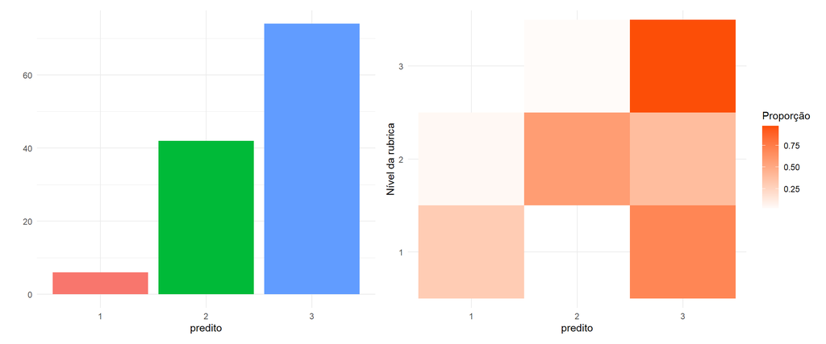

```r
p1$barras + p1$matriz
```

Probabilidades da resposta pertencer a categoria predita nos casos em que houve acerto.

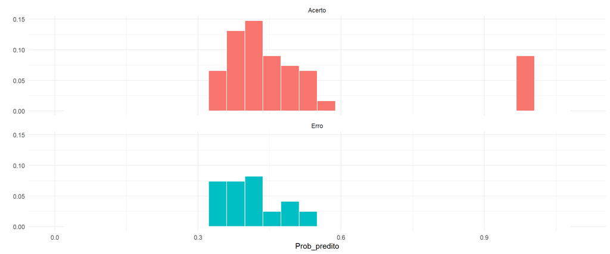

```r
probabilidades_cluster(1, centroides, alunos) %>%
  ggplot(aes(x = Prob_predito, y = ..count../sum(..count..), fill = Comp)) +
  geom_histogram(color = "white") +
  facet_wrap(vars(Comp), nrow = 2) +
  xlim(0, 1.1) +
  labs(y = "") + theme(legend.position = "none")
```

## Pergunta 2

| Pergunta | Nível da rubrica | n | Predito |
| --- | --- | --- | --- |
| Quem é Darlan Rosa? | 1 | 1 | NA |
| Quem é Darlan Rosa? | 2 | 27 | 28 |
| Quem é Darlan Rosa? | 3 | 108 | 96 |

```r
p2$perc_acerto
```

[1] “A proporção de acerto é igual a 85 %.”

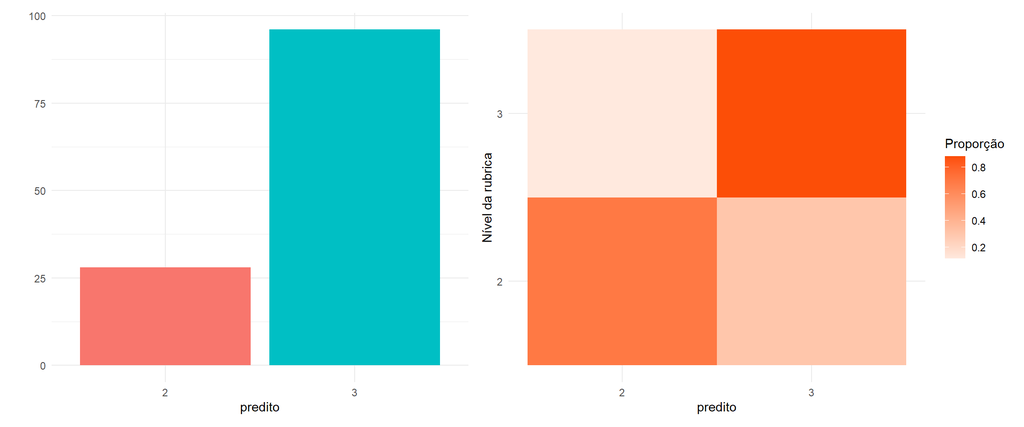

```r
p2$barras + p2$matriz
```

Probabilidades da resposta pertencer a categoria predita nos casos em que houve acerto.

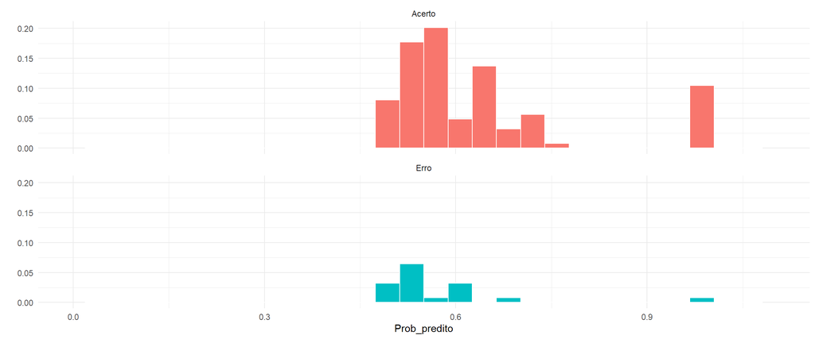

```r
probabilidades_cluster(2, centroides,
                     alunos %>% filter(`Nível da rubrica` != 1)) %>%
  ggplot(aes(x = Prob_predito, y = ..count../sum(..count..), fill = Comp)) +
  geom_histogram(color = "white") +
  facet_wrap(vars(Comp), nrow = 2) +
  xlim(0, 1.1) +
  labs(y = "") + theme(legend.position = "none")
```

## Pergunta 3

| Pergunta | Nível da rubrica | n | Predito |
| --- | --- | --- | --- |
| Como eram as propagandas de vacina antes da criação do Zé Gotinha? | 1 | 26 | 22 |
| Como eram as propagandas de vacina antes da criação do Zé Gotinha? | 2 | 84 | 41 |
| Como eram as propagandas de vacina antes da criação do Zé Gotinha? | 3 | 26 | 62 |

```r
p3$perc_acerto
```

[1] “A proporção de acerto é igual a 64 %.”

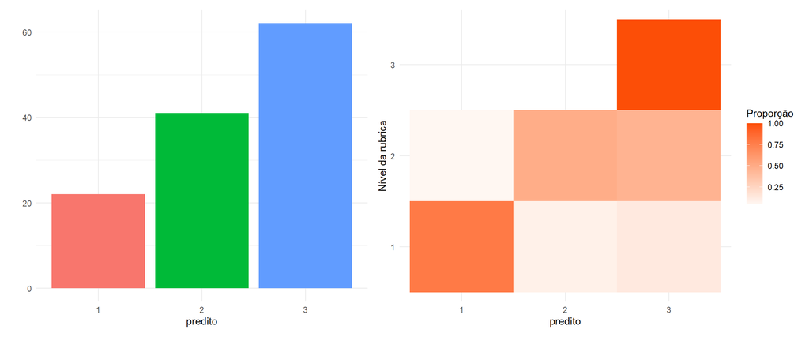

```r
p3$barras + p3$matriz
```

Probabilidades da resposta pertencer a categoria predita nos casos em que houve acerto.

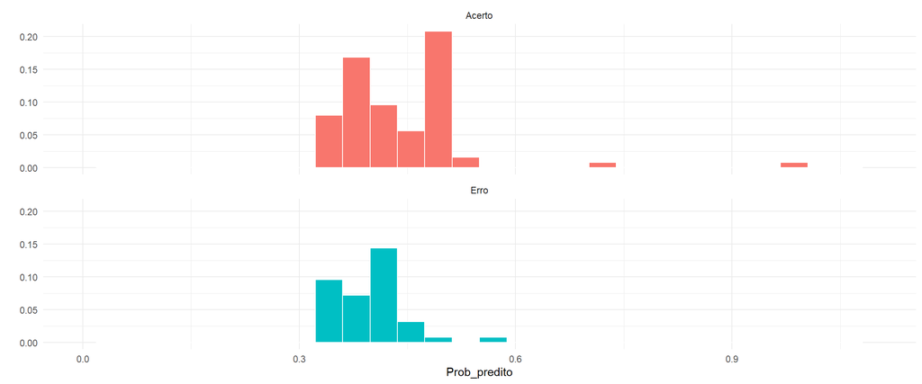

```r
probabilidades_cluster(3, centroides, alunos) %>%
  ggplot(aes(x = Prob_predito, y = ..count../sum(..count..), fill = Comp)) +
  geom_histogram(color = "white") +
  facet_wrap(vars(Comp), nrow = 2) +
  xlim(0, 1.1) +
  labs(y = "") + theme(legend.position = "none")
```

## Pergunta 4

| Pergunta | Nível da rubrica | n | Predito |
| --- | --- | --- | --- |
| Quando o Zé Gotinha foi criado? | 1 | 3 | NA |
| Quando o Zé Gotinha foi criado? | 3 | 133 | 130 |

```r
p4$perc_acerto
```

[1] “A proporção de acerto é igual a 100 %.”

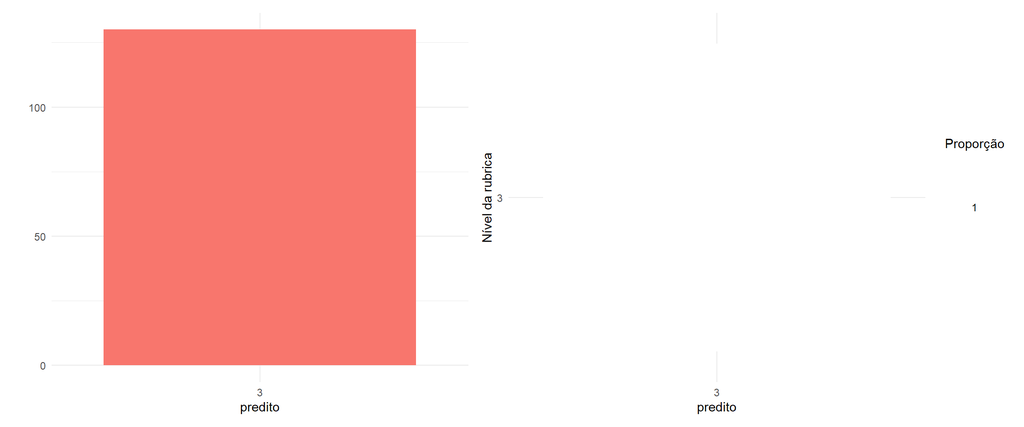

```r
p4$barras + p4$matriz
```

Probabilidades da resposta pertencer a categoria predita nos casos em que houve acerto.

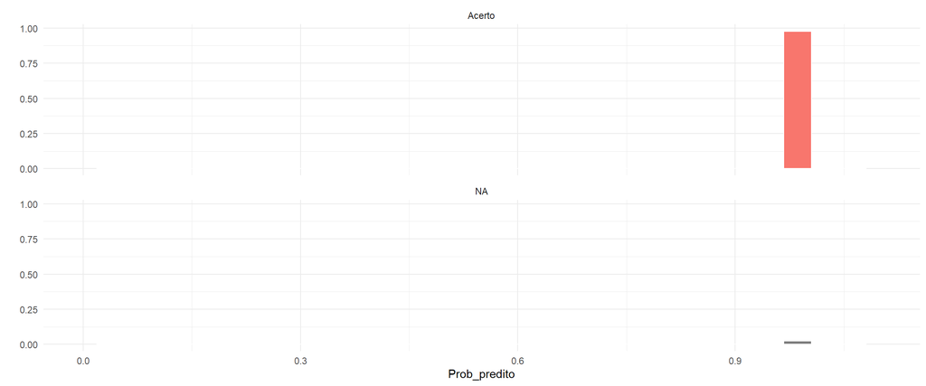

```r
probabilidades_cluster(4, centroides, alunos) %>%
  ggplot(aes(x = Prob_predito, y = ..count../sum(..count..), fill = Comp)) +
  geom_histogram(color = "white") +
  facet_wrap(vars(Comp), nrow = 2) +
  xlim(0, 1.1) +
  labs(y = "") + theme(legend.position = "none")
```

## Pergunta 5

```r
p5 <- conglomerado_pergunta(5, centroides, alunos)

# todas_obs5 <- rbind(centroides %>% filter(pergunta_id == 5),
#                     alunos %>% select(-1) %>% filter(pergunta_id == 5))
# n_ouro5 <- nrow(centroides %>% filter(pergunta_id == 5))
# n_teste5 <- nrow(alunos %>% select(-1) %>% filter(pergunta_id == 5))
#
# class5 <- get_dist(todas_obs5[,3:52]) %>% as.matrix %>%
#   .[(n_ouro5+1):(n_teste5+n_ouro5), 1:n_ouro5] %>% as.data.frame() %>%
#   rename_with(~ paste0("V", .)) %>%
#   mutate(id = alunos %>% filter(pergunta_id == 5) %>% pull(estudante_id)) %>%
#   pivot_longer(cols = starts_with("V"), names_to = "Centroide",
#                values_to = "Valores") %>%
#   group_by(id) %>%
#   filter(Valores == min(Valores)) %>%
#   mutate(predito = str_replace(Centroide, "V", "")) %>%
#   rename(estudante_id = id)
#
# banco5 <- alunos %>% filter(pergunta_id == 5) %>%
#   left_join(class5 %>% select(estudante_id, predito))
#
# barras5 <- banco5 %>%
#   ggplot(aes(predito, fill = predito)) +
#   geom_bar() + labs(y = "") + theme_minimal() +
#   theme(legend.position = "none")
#
# matriz5 <- banco5 %>%
#   group_by(predito, `Nível da rubrica`) %>%
#   count() %>%
#   group_by(`Nível da rubrica`) %>%
#   mutate("Proporção" = n/sum(n)) %>%
#   ggplot(aes(x = predito, y =`Nível da rubrica`, fill = `Proporção`)) +
#   geom_tile() +
#   scale_fill_gradient2(low = "#00AFBB", high = "#FC4E05")
#
# perc_acerto5_n <- banco5 %>%
#   mutate(acerto = (predito == `Nível da rubrica`)) %>%
#   pull(acerto) %>% sum()/n_teste5
# perc_acerto5 <- paste("A proporção de acerto é igual a", round(perc_acerto5_n, 2)*100,"%.")
#
# p5 <- list(barras = barras5,
#            matriz = matriz5,
#            perc_acerto = perc_acerto5,
#            perc_acerto_n  = perc_acerto5_n,
#            banco = banco5)
```

| Pergunta | Nível da rubrica | n | Predito |
| --- | --- | --- | --- |
| Quando nasceu, Zé Gotinha era diferente do que é hoje. Descreva as características do Zé Gotinha quando nasceu. Em seguida, descreva como ele é atualmente. | 1 | 24 | 13 |
| Quando nasceu, Zé Gotinha era diferente do que é hoje. Descreva as características do Zé Gotinha quando nasceu. Em seguida, descreva como ele é atualmente. | 2 | 73 | 44 |
| Quando nasceu, Zé Gotinha era diferente do que é hoje. Descreva as características do Zé Gotinha quando nasceu. Em seguida, descreva como ele é atualmente. | 3 | 39 | 62 |

```r
p5$perc_acerto
```

[1] “A proporção de acerto é igual a 52 %.”

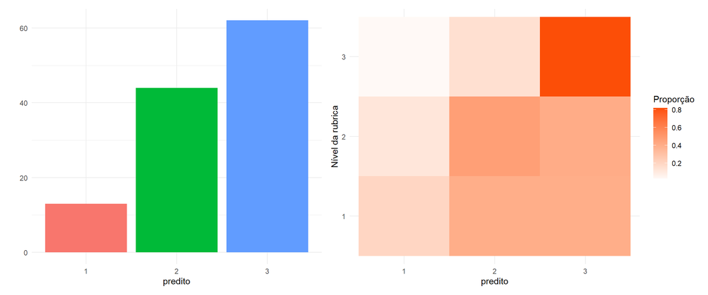

```r
p5$barras + p5$matriz
```

Probabilidades da resposta pertencer a categoria predita nos casos em que houve acerto.

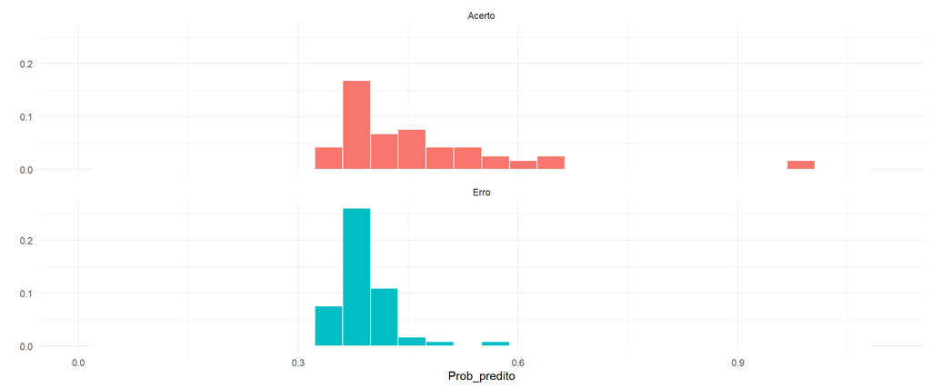

```r
probabilidades_cluster(5, centroides, alunos) %>%
  ggplot(aes(x = Prob_predito, y = ..count../sum(..count..), fill = Comp)) +
  geom_histogram(color = "white") +
  facet_wrap(vars(Comp), nrow = 2) +
  xlim(0, 1.1) +
  labs(y = "") + theme(legend.position = "none")
```